# 2 Get started with positron

**Positron’s core layout components**

The overall layout is pretty close to the one of RStudio, with a mix of Visual Studio Code (VS Code). Positron introduces the **Activity Bar** and **Primary Side Bar** for accessing features like file exploration, search, and Git control, replacing many specialized RStudio panes and buttons.

Positron’s UI has 5 components :

- **Activity Bar:**
  - Access the Explorer
  - Search
  - Source Control
  - Extensions
  - Other views
- **Primary Side Bar:** Shows different views depending on what you have chosen in the Activity Bar
  - When the Explorer is chosen, the Primary Side Bar provides a file explorer
- **Editor:** Where you write your code
- **Panel:** Contains the Console and Terminal
- **Secondary Side Bar:** Explore variables, view plots, access documentation, and more

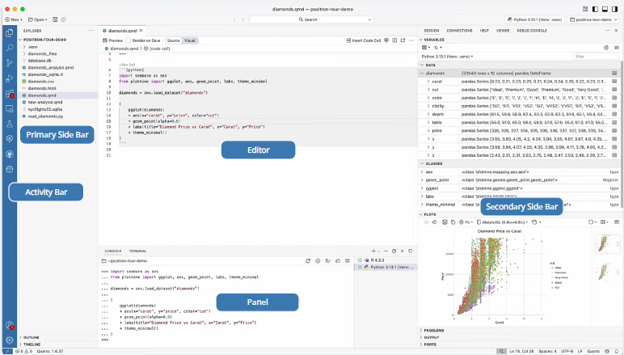

Figure 10 : positron’s layout components

> Positron also provides an **AI Assistance: Positron Assistant & Databot**

One of Positron’s most innovative features is the Positron Assistant, a native Generative AI client. This AI assistant is more than just a coding chatbot; it is **context-aware** and **can access information from your console, variables, and plots**. It can help you with:

- **Generating code**: Writing boilerplate code or suggesting functions for a given task.
- **Debugging code:** Identifying and explaining errors in your code.
- **Understanding code**: Explaining the syntax and purpose of your code. Positron also includes *Databot*, an exploratory data analysis agent who acts like a research assistant that explores and visualizes data, then recommends next steps.

To download positron, let’s go to [posit](https://posit.co/homepage-b/) website : https://positron.posit.co/